# Package MKomics

Matthias Kohl

2021-08-08

## Introduction

Package MKomics includes a collection of functions that I found and find useful for the analysis of omics data. It includes:

- similarity plots based on correlation and median absolute deviation (MAD)
- adjusting colors for heatmaps
- aggregate technical replicates
- calculate pairwise fold-changes and log fold-changes
- compute one- and two-way ANOVA
- simplified interface to package ‘limma’ (Ritchie et al. 2015) for moderated t-test and one-way ANOVA
- Hamming and the Levenshtein (edit) distance of strings as well as optimal alignment scores for global (Needleman-Wunsch) and local (Smith-Waterman) alignments with constant gap penalties (Merkl and Waack 2009).

The package requires Bioconductor package limma, which can be installed via

```r
## Install package BiocManager
install.packages("BiocManager")
## Use BiocManager to install limma
BiocManager::install("limma")
```

We first load the package.

```r
library(MKomics)
```

## Moderated Tests Based on Package limma

The functions to compute the moderated t-test and one-way ANOVA were motivated by the fact that my students had problems to understand and correctly adapt the code of the limma package (Ritchie et al. 2015).

### Moderated t-Test

We generate some artificial data and compute moderated t-tests.

```r
## One-sample test
X <- matrix(rnorm(10*20, mean = 1), nrow = 10, ncol = 20)
mod.t.test(X)
```

```
##         mean      2.5%    97.5%        t      p.value  adj.p.value          B
## 1  0.8167034 0.3347307 1.298676 3.342451 1.000055e-03 1.250069e-03 -1.2889029
## 2  0.8597711 0.3777984 1.341744 3.518711 5.425967e-04 9.043279e-04 -0.6914649
## 3  0.8024507 0.3204780 1.284423 3.284121 1.217895e-03 1.353217e-03 -1.4798576
## 4  1.1286441 0.6466713 1.610617 4.619104 7.092114e-06 2.364038e-05  3.7323676
## 5  0.7657581 0.2837853 1.247731 3.133952 1.998232e-03 1.998232e-03 -1.9559897
## 6  1.2950566 0.8130838 1.777029 5.300166 3.189578e-07 1.594789e-06  7.0697754
## 7  1.0246341 0.5426613 1.506607 4.193431 4.210188e-05 8.420376e-05  1.8791782
## 8  1.5096517 1.0276790 1.991624 6.178421 3.856033e-09 3.856033e-08 12.0500350
## 9  0.8280052 0.3460325 1.309978 3.388705 8.537765e-04 1.219681e-03 -1.1350943
## 10 1.0959262 0.6139534 1.577899 4.485202 1.258857e-05 3.147142e-05  3.1301177
```

```r
## Two-sample test
set.seed(123)
X <- rbind(matrix(rnorm(5*20), nrow = 5, ncol = 20),
           matrix(rnorm(5*20, mean = 1), nrow = 5, ncol = 20))
g2 <- factor(c(rep("group 1", 10), rep("group 2", 10)))
mod.t.test(X, group = g2)
```

```
##    difference in means       2.5%     97.5%           t   p.value adj.p.value
## 1           0.30099317 -0.5318079 1.1337943  0.71317027 0.4766640   0.9665915
## 2          -0.13637650 -0.9691776 0.6964246 -0.32312914 0.7469725   0.9665915
## 3           0.49260925 -0.3401919 1.3254104  1.16718354 0.2446801   0.8156005
## 4          -0.15266680 -0.9854679 0.6801343 -0.36172723 0.7179801   0.9665915
## 5           0.05546448 -0.7773366 0.8882656  0.13141699 0.8955922   0.9665915
## 6           0.03152278 -0.8012783 0.8643239  0.07468976 0.9405445   0.9665915
## 7           0.69311916 -0.1396820 1.5259203  1.64226977 0.1022800   0.8156005
## 8           0.17595066 -0.6568505 1.0087518  0.41689577 0.6772514   0.9665915
## 9           0.54524220 -0.2875589 1.3780433  1.29189154 0.1980510   0.8156005
## 10          0.01770155 -0.8150996 0.8505027  0.04194188 0.9665915   0.9665915
##            B mean of group 1 mean of group 2
## 1  -4.608912      0.07083562     0.371828786
## 2  -4.619655      0.13562592    -0.000750575
## 3  -4.586223     -0.30436677     0.188242477
## 4  -4.618953      0.18497579     0.032308986
## 5  -4.621971      0.08494719     0.140411667
## 6  -4.622282      1.11828347     1.149806246
## 7  -4.550748      0.67404426     1.367163425
## 8  -4.617811      0.53111339     0.707064052
## 9  -4.578072      0.92210638     1.467348578
## 10 -4.622384      0.48495033     0.502651884
```

```r
## Paired two-sample test
subjID <- factor(rep(1:10, 2))
mod.t.test(X, group = g2, paired = TRUE, subject = subjID)
```

```
##    mean of differences       2.5%     97.5%           t   p.value adj.p.value
## 1           0.30099317 -0.5606128 1.1625992  0.69402426 0.4894545   0.9675331
## 2          -0.13637650 -0.9979825 0.7252295 -0.31445430 0.7539038   0.9675331
## 3           0.49260925 -0.3689968 1.3542152  1.13584893 0.2590354   0.8634514
## 4          -0.15266680 -1.0142728 0.7089392 -0.35201618 0.7256490   0.9675331
## 5           0.05546448 -0.8061415 0.9170705  0.12788893 0.8985222   0.9675331
## 6           0.03152278 -0.8300832 0.8931288  0.07268461 0.9422184   0.9675331
## 7           0.69311916 -0.1684868 1.5547252  1.59818084 0.1135079   0.8634514
## 8           0.17595066 -0.6856553 1.0375567  0.40570365 0.6859233   0.9675331
## 9           0.54524220 -0.3163638 1.4068482  1.25720898 0.2119307   0.8634514
## 10          0.01770155 -0.8439044 0.8793075  0.04081589 0.9675331   0.9675331
##            B mean of group 1 mean of group 2
## 1  -4.608863      0.07083562     0.371828786
## 2  -4.618525      0.13562592    -0.000750575
## 3  -4.588455     -0.30436677     0.188242477
## 4  -4.617893      0.18497579     0.032308986
## 5  -4.620608      0.08494719     0.140411667
## 6  -4.620887      1.11828347     1.149806246
## 7  -4.556550      0.67404426     1.367163425
## 8  -4.616866      0.53111339     0.707064052
## 9  -4.581125      0.92210638     1.467348578
## 10 -4.620978      0.48495033     0.502651884
```

### Moderated 1-Way ANOVA

We generate some artifical data and compute moderated one-way ANOVAs.

```r
set.seed(123)
X <- rbind(matrix(rnorm(5*20), nrow = 5, ncol = 20),
           matrix(rnorm(5*20, mean = 1), nrow = 5, ncol = 20))
gr <- factor(c(rep("A1", 5), rep("B2", 5), rep("C3", 5), rep("D4", 5)))
mod.oneway.test(X, gr)
```

```
## topTableF is obsolete and will be removed in a future version of limma. Please considering using topTable instead.
```

```
##      A1 vs B2   A1 vs C3    A1 vs D4    B2 vs C3   B2 vs D4    C3 vs D4
## 1   1.0974330  0.2271669  0.26827976 -0.87026609 -0.8291532  0.04111286
## 2   0.0769194  0.9622020 -0.61252965  0.88528264 -0.6894491 -1.57473169
## 3  -0.3105477 -0.7130963 -0.58266984 -0.40254866 -0.2721221  0.13042651
## 4  -0.5832304 -0.2440290 -0.03386782  0.33920142  0.5493626  0.21016117
## 5  -0.9579128 -0.4501003 -0.61874146  0.50781250  0.3391713 -0.16864116
## 6  -0.6013595 -0.5109767 -0.15342834  0.09038278  0.4479311  0.35754833
## 7   0.3471695 -0.3493145 -0.68975433 -0.69648400 -1.0369239 -0.34043986
## 8  -0.9277388 -0.5691081 -0.71053196  0.35863064  0.2172068 -0.14142382
## 9  -0.5998638 -1.5488157 -0.14153255 -0.94895185  0.4583313  1.40728311
## 10  1.5527067  0.5179562  0.99934740 -1.03475050 -0.5533593  0.48139118
##     grand mean         F    p.value adj.p.value
## 1   0.22133220 1.4119467 0.23709800   0.5868380
## 2   0.06743767 2.5678204 0.05255479   0.1751826
## 3  -0.05806215 0.6094415 0.60879068   0.7253749
## 4   0.10864239 0.4386138 0.72537489   0.7253749
## 5   0.11267943 0.9691456 0.40611786   0.5868380
## 6   1.13404486 0.5002131 0.68212276   0.7253749
## 7   1.02060384 1.2185746 0.30111975   0.5868380
## 8   0.61908872 0.9594030 0.41078662   0.5868380
## 9   1.19472748 2.9871234 0.02980893   0.1751826
## 10  0.49380111 2.6903326 0.04456696   0.1751826
```

We can also perform a moderated one-way ANOVA with repeated measures.

```r
X <- rbind(matrix(rnorm(6*18), nrow = 6, ncol = 18),
           matrix(rnorm(6*18, mean = 1), nrow = 6, ncol = 18))
gr <- factor(c(rep("T1", 6), rep("T2", 6), rep("T3", 6)))
subjectID <- factor(c(rep(1:6, 3)))
mod.oneway.test(X, gr, repeated = TRUE, subject = subjectID)
```

```
##      grand mean          F    p.value adj.p.value
## 1   0.439887277 0.24258038 0.91426233   0.9856427
## 2  -0.348176298 0.25294001 0.90800757   0.9856427
## 3  -0.001648741 0.19504576 0.94108489   0.9856427
## 4   0.380034581 0.64717729 0.62882454   0.9856427
## 5   0.116088830 0.19890913 0.93903209   0.9856427
## 6  -0.215112459 0.13298495 0.97031807   0.9856427
## 7   1.305439170 0.08992079 0.98564266   0.9856427
## 8   0.927363547 2.87518053 0.02147716   0.2577260
## 9   1.057394093 1.60523754 0.16983981   0.6793592
## 10  0.985162868 1.66804543 0.15425972   0.6793592
## 11  0.780801913 0.48820193 0.74443860   0.9856427
## 12  0.787626019 0.45961349 0.76543996   0.9856427
```

### Pairwise moderated t-tests

As a optional post-hoc analysis after mod.oneway.test one can use pairwise moderated t-tests (only unpaired). One should carefully think about the adjustment of p values in this context.

```r
pairwise.mod.t.test(X, gr)
```

```
##         T1-T2   T1-T2: t    T1-T2: p T1-T2: adj.p  T1-T2: B       T1-T3
## 1   0.2342401  0.4014278 0.688581325   0.82059173 -5.803960 -0.05487846
## 2   0.2423784  0.4153749 0.678362198   0.82059173 -5.798701  0.24537369
## 3  -0.1966000 -0.3369222 0.736568028   0.82059173 -5.825944 -0.13384174
## 4  -0.2086677 -0.3576033 0.721059196   0.82059173 -5.819314 -0.26788464
## 5  -0.1845143 -0.3162105 0.752209088   0.82059173 -5.832189  0.17817385
## 6  -0.2977183 -0.5102134 0.610527064   0.82059173 -5.758182 -0.34726718
## 7  -0.3016336 -0.5169231 0.605844436   0.82059173 -5.755000 -0.01197801
## 8   1.6357283  2.8032215 0.005614332   0.06737198 -2.251098  1.58693190
## 9   0.4583369  0.7854726 0.433209202   0.82059173 -5.593554  0.46639256
## 10 -0.2211433 -0.3789833 0.705146931   0.82059173 -5.812045 -0.19783574
## 11  0.4886687  0.8374536 0.403448173   0.82059173 -5.554613  0.54861003
## 12  0.1275920  0.2186602 0.827162496   0.82716250 -5.856273  0.33974584
##       T1-T3: t    T1-T3: p T1-T3: adj.p  T1-T3: B        T2-T3     T2-T3: t
## 1  -0.09404770 0.925175869   0.98364550 -5.806707 -0.289118564 -0.495475544
```

[output cut: 24 more lines]

## Pairwise Comparisons

Often we are in a situation that we want to compare more than two groups pairwise.

### FC and logFC

In the analysis of omics data, the FC or logFC are important measures of effect size and are often used in combination with (adjusted) p values (Shi et al. 2006).

```r
x <- rnorm(100) ## assumed as log-data
g <- factor(sample(1:4, 100, replace = TRUE))
levels(g) <- c("a", "b", "c", "d")
## modified FC
pairwise.fc(x, g)
```

```
##    a vs b    a vs c    a vs d    b vs c    b vs d    c vs d
##  1.444915  1.232566  1.347226 -1.172281 -1.072511  1.093025
```

```r
## "true" FC
pairwise.fc(x, g, mod.fc = FALSE)
```

```
##    a vs b    a vs c    a vs d    b vs c    b vs d    c vs d
## 1.4449145 1.2325662 1.3472261 0.8530375 0.9323915 1.0930253
```

```r
## without any transformation
pairwise.logfc(x, g)
```

```
##     a vs b     a vs c     a vs d     b vs c     b vs d     c vs d
##  0.5309842  0.3016652  0.4299920 -0.2293190 -0.1009922  0.1283268
```

The function returns a modified FC. That is, if the FC is smaller than 1 it is transformed to -1/FC. One can also use other functions than the mean for the aggregation of the data.

```r
pairwise.logfc(x, g, ave = median)
```

```
##     a vs b     a vs c     a vs d     b vs c     b vs d     c vs d
##  0.6128841  0.2182627  0.4992445 -0.3946214 -0.1136396  0.2809818
```

## Aggregating Technical Replicates

In case of omics experiments it is often the case that technical replicates are measured and hence it is part of the preprocessing of the raw data to aggregate these technical replicates. This is the purpose of function repMeans.

```r
M <- matrix(rnorm(100), ncol = 5)
FL <- matrix(rpois(100, lambda = 10), ncol = 5) # only for this example
repMeans(x = M, flags = FL, use.flags = "max", ndups = 5, spacing = 4)
```

```
## $exprs
##             [,1]       [,2]       [,3]       [,4]        [,5]
## [1,] -1.18155923  0.2353980  0.9606907  0.1573533 -1.93850470
## [2,]  1.37000399 -1.5160676  0.1781902 -0.4929374  0.12071933
## [3,] -0.54174319  0.8405398 -0.2997625 -0.8341882  0.86364843
## [4,] -0.07335999 -0.2858454  0.3183903  0.8993541 -0.03515489
##
## $flags
##      [,1] [,2] [,3] [,4] [,5]
## [1,]   11   14   12   14   16
## [2,]   13   13   13   21   13
## [3,]   11   15   18   14   17
## [4,]   13   15   13   14   11
```

## 1- and 2-Way ANOVA

Functions oneWayAnova and twoWayAnova return a function that can be used to perform a 1- or 2-way ANOVA, respectively.

```r
af <- oneWayAnova(c(rep(1,5),rep(2,5)))
## p value
af(rnorm(10))
```

```
## [1] 0.3936899
```

```r
x <- matrix(rnorm(12*10), nrow = 10)
## 2-way ANOVA with interaction
af1 <- twoWayAnova(c(rep(1,6),rep(2,6)), rep(c(rep(1,3), rep(2,3)), 2))
## p values
apply(x, 1, af1)
```

```
##                  [,1]      [,2]      [,3]      [,4]      [,5]      [,6]
## cov1        0.7189770 0.1199344 0.7797292 0.3399445 0.4791519 0.3287401
## cov2        0.1248696 0.1246937 0.2553811 0.5648113 0.6118778 0.0463841
## interaction 0.3941863 0.1489906 0.9090044 0.1403097 0.1257246 0.8367084
##                  [,7]      [,8]       [,9]     [,10]
## cov1        0.4046772 0.8125137 0.01638546 0.7791182
## cov2        0.2884822 0.7388120 0.85514661 0.8902903
## interaction 0.2453559 0.7667181 0.20801934 0.2081726
```

```r
## 2-way ANOVA without interaction
af2 <- twoWayAnova(c(rep(1,6),rep(2,6)), rep(c(rep(1,3), rep(2,3)), 2),
                   interaction = FALSE)
## p values
apply(x, 1, af2)
```

```
##           [,1]      [,2]      [,3]      [,4]      [,5]       [,6]      [,7]
## cov1 0.7150619 0.1423638 0.7661585 0.3758909 0.5173798 0.29988569 0.4157757
## cov2 0.1172529 0.1476506 0.2264692 0.5948831 0.6432147 0.03443076 0.2988795
##           [,8]       [,9]     [,10]
## cov1 0.8018355 0.01789566 0.7880695
## cov2 0.7242262 0.86114929 0.8948589
```

## Correlation Distance Matrix

In the analysis of omics data correlation and absolute correlation distance matrices are often used during quality control. Function corDist can compute the Pearson, Spearman, Kendall or Cosine sample correlation and absolute correlation as well as the minimum covariance determinant or the orthogonalized Gnanadesikan-Kettenring correlation and absolute correlation implemented in package robustbase (Maechler et al. 2019).

```r
M <- matrix(rcauchy(1000), nrow = 5)
## Pearson
corDist(M)
```

```
##           1         2         3         4
## 2 0.2875716
## 3 0.9914823 1.0146980
## 4 0.9961413 0.9955740 1.0016289
## 5 1.0063069 0.9774429 1.0012735 1.0165059
```

```r
## Spearman
corDist(M, method = "spearman")
```

```
##           1         2         3         4
## 2 1.0801350
## 3 0.9244866 1.0314483
## 4 1.0515473 0.9741859 1.1059056
## 5 1.0247986 0.9784685 0.9892507 0.9815645
```

```r
## Minimum Covariance Determinant
corDist(M, method = "mcd")
```

```
##           1         2         3         4
## 2 0.9298225
## 3 0.9496162 1.0243463
## 4 1.0301798 0.9683927 1.0295911
## 5 0.9421068 0.9974223 1.1032783 0.8426071
```

## MAD Matrix

In case of outliers the MAD (median absolute deviation = median of the absolute deviations from the median) may be useful as measure of scale.

```r
madMatrix(t(M))
```

```
##          [,1]     [,2]     [,3]     [,4]     [,5]
## [1,] 0.000000 3.118364 3.006511 2.974456 2.878586
## [2,] 3.118364 0.000000 2.617500 2.612594 2.474732
## [3,] 3.006511 2.617500 0.000000 3.278506 3.096261
## [4,] 2.974456 2.612594 3.278506 0.000000 2.899905
## [5,] 2.878586 2.474732 3.096261 2.899905 0.000000
```

## Similarity Matrices

First, we can plot a similarity matrix based on correlation.

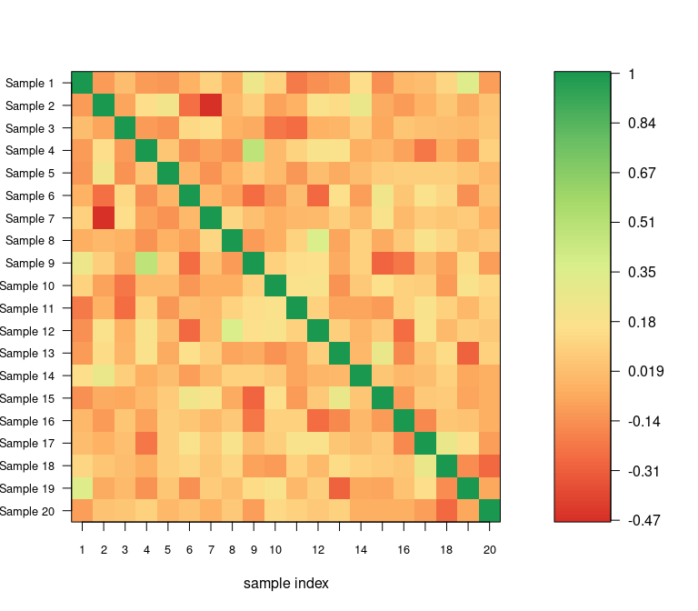

```r
M <- matrix(rnorm(1000), ncol = 20)
colnames(M) <- paste("Sample", 1:20)
M.cor <- cor(M)
corPlot(M.cor, minCor = min(M.cor), labels = colnames(M))
```

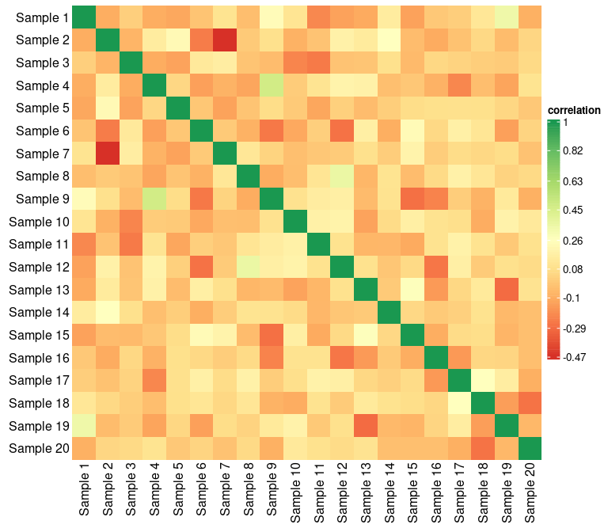

```r
corPlot2(M.cor, minCor = min(M.cor), labels = colnames(M))
```

Next, we can use the MAD.

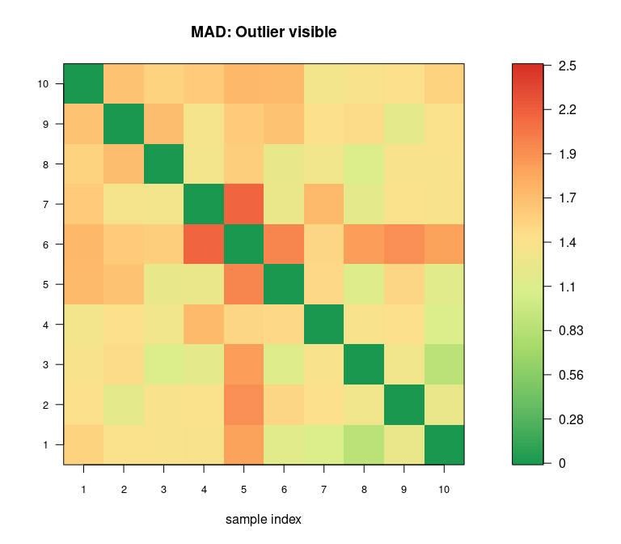

```r
## random data
x <- matrix(rnorm(1000), ncol = 10)
## outliers
x[1:20,5] <- x[1:20,5] + 10
madPlot(x, new = TRUE, maxMAD = 2.5, labels = TRUE,
        title = "MAD: Outlier visible")
```

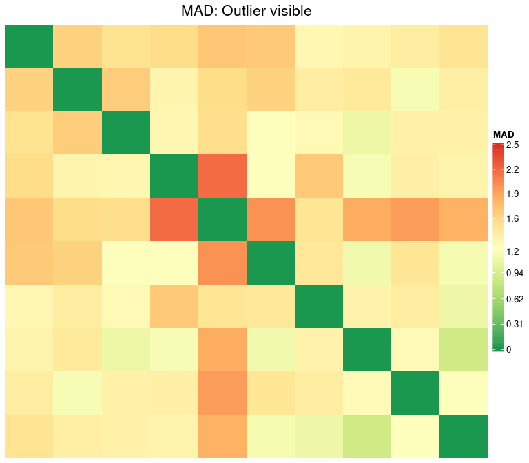

```r
madPlot2(x, new = TRUE, maxMAD = 2.5, labels = TRUE,
        title = "MAD: Outlier visible")
```

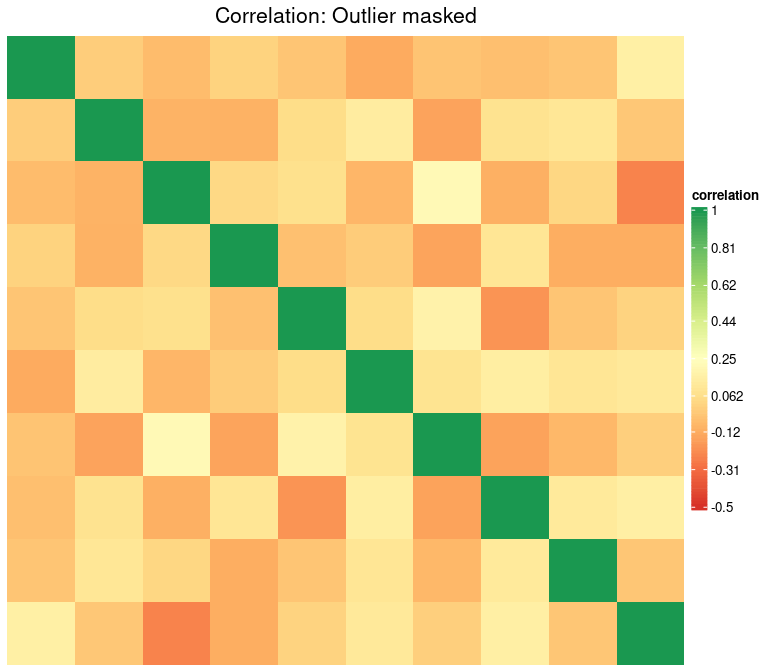

```r
## in contrast
corPlot2(x, new = TRUE, minCor = -0.5, labels = TRUE,
        title = "Correlation: Outlier masked")
```